# Hidden Markov Models in R

A self-study module with exercises and solutions

Author

Course module — material drawn from recent ecological HMM papers

Published

October 6, 2026

# About this module

This module is a **first introduction to hidden Markov models (HMMs)**. It assumes you have never seen one. We start from the idea of a system that switches between a few states, build an HMM by *simulating* from it, and only then fit one to real ecological data.

HMMs have become one of the standard tools in quantitative ecology. They are used to classify animal behaviour from tracking data, to detect regime shifts in ecosystem indicators, to model disease state in capture–recapture studies and to estimate occupancy from camera traps. All of those examples appear in the papers collected in `.hmm_papers/` (see zip-archive on canvas).

## Learning objectives

After working through this module you should be able to:

1. explain what the **hidden state** and the **observation model** of an HMM are, and why ecologists need both;
2. read and use a **transition matrix**: row sums, persistence, $k$-step transitions, expected dwell time and the stationary distribution;
3. **simulate** data from a two-state HMM, and see how the parameters shape the series;
4. **fit** an HMM in R with `depmixS4` and read its output (transition matrix, state means, log-likelihood);
5. **decode** the hidden states — both the most likely path (Viterbi) and the state probabilities — and judge how certain they are;
6. choose the **number of states** with AIC/BIC *and* know why that choice is never purely automatic;
7. recognise in a published paper what plays the role of the hidden state, the observation model and the covariates.

## How to use this module

- **Time:** about 3–4 hours. Part I (Sections 1–6) takes roughly 1.5 hours, the two worked examples 45 minutes, the exercises the rest.
- **Prerequisites:** basic R (vectors, data frames, `for()` loops, plotting), `glm()` for logistic regression, and the ideas of likelihood and AIC. The Monte Carlo module is useful preparation, because we simulate a lot here.
- **Working style:** open a new script (e.g. `HMM_self_study.R`) and *type* the code yourself. Run each line and look at what it produces.
- **Exercises** are in Part III. Solutions are in collapsed boxes — **make a serious attempt first**.
- Several results are random, so your numbers will differ slightly from the ones printed here unless you use the same `set.seed()`.

## Setup

We need one extra package, `depmixS4`. Install it once:

```r
install.packages("depmixS4")
```

and load it at the start of every session:

```r
library(depmixS4)
```

Everything else is base R. The two data sets we use are:

- `Nile` — annual flow of the river Nile, available in base R (`datasets::Nile`), 100 values for 1871–1970;
- a table of **123 Minnesota shallow lakes** sampled in 2009–2011, from the data archive of Vitense et al. (2021). Unpack `hmm_papers.zip` next to this file; the table is then at `hmm_papers/Vitense2021_JApplEcol_shallow_lakes/data/HMM/Data/State.csv`.

```r
lake_file <- file.path("hmm_papers", "Vitense2021_JApplEcol_shallow_lakes",
                       "data", "HMM", "Data", "State.csv")
if (!file.exists(lake_file)) {           # fallback: full course folder layout
  lake_file <- file.path("..", lake_file)
}
lakes <- read.csv(lake_file)
dim(lakes)
```

```
[1] 123  19
```

**NoteWhat is a hidden Markov model?**

An HMM describes a system that is, at any moment, in **one of a few discrete states** — and you cannot see which. You only see **data generated by the current state**. The model therefore has two layers:

1. a **hidden state process**: the state at time $t$ depends only on the state at time $t-1$ (that is the *Markov* part), with probabilities collected in a transition matrix;
2. an **observation model**: given the state, the data follow some distribution, e.g. a normal with a state-specific mean.

Fitting an HMM means estimating both layers from the data alone, and then asking which state the system was probably in at each time step. An ecological example: a lake is *clear* or *turbid* (hidden state), and we observe a noisy chlorophyll measurement each summer (observation).

# Part I – Required material

# 1 The two layers of an HMM

Suppose an ocean region is in a **cool** or a **warm** regime, and each year we measure sea surface temperature. The regime is not written down anywhere — it is *hidden* — but it leaves a trace in the measurements.

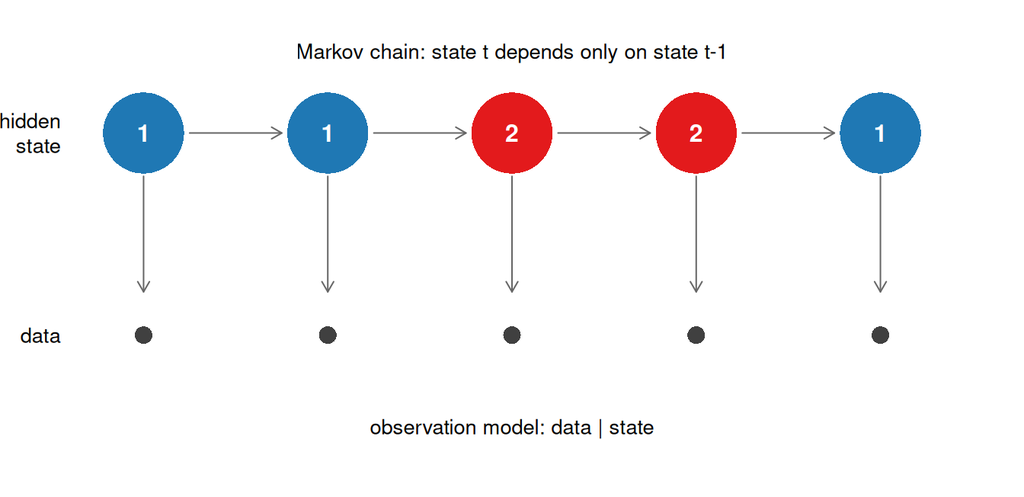

Figure 1

Two questions follow immediately, and the two layers answer them:

| Question | Answered by |
| --- | --- |
| How does the system move between states? | the **transition matrix** $\Gamma$ |
| What do the data look like in each state? | the **observation model** |

**Important**

The number of states is **not** estimated by the model — *you* choose it (see Section 6). Everything else is estimated from the data.

# 2 Transition probabilities

Call the state at time $t$ $x_t$, taking values $1, \dots, N$. The sequence is a **Markov chain** if the next state depends only on the current one:

$$\Pr(x_{t+1} \mid x_t, x_{t-1}, \dots, x_1) = \Pr(x_{t+1} \mid x_t).$$

The probability of moving from state $i$ to state $j$ is written $\gamma_{ij}$, and these are collected in the **transition matrix**:

$$\Gamma = \begin{bmatrix} \gamma_{11} & \gamma_{12} \\
\gamma_{21} & \gamma_{22}\end{bmatrix},
\qquad \sum_j \gamma_{ij} = 1 \text{ for every row } i.$$

In R a transition matrix is simply a matrix whose rows sum to one. Note `byrow = TRUE`: it makes the code read in the same order as the maths.

```r
Gamma <- matrix(c(0.9, 0.1,
                  0.2, 0.8), nrow = 2, byrow = TRUE)
rownames(Gamma) <- c("from 1", "from 2")
colnames(Gamma) <- c("to 1", "to 2")
Gamma
```

```
       to 1 to 2
from 1  0.9  0.1
from 2  0.2  0.8
```

```r
rowSums(Gamma)
```

```
from 1 from 2
     1      1
```

Read it row by row: *if we are in state 1 now, we stay with probability 0.9 and switch with probability 0.1.*

## 2.1 Three things you can read off $\Gamma$

**1. Persistence and expected dwell time.** The diagonal says how sticky a state is. The expected length of a run in state $i$ is

$$\mathbb{E}[\text{run length in } i] = \frac{1}{1 - \gamma_{ii}}.$$

```r
1 / (1 - diag(Gamma))
```

```
[1] 10  5
```

So state 1 lasts 10 time steps on average and state 2 lasts 5.

**2. $k$-step transitions.** The probabilities of where we are $k$ steps from now are given by the matrix power $\Gamma^k$. In R, `%*%` is matrix multiplication (`*` would multiply element by element — a classic mistake):

```r
Gamma %*% Gamma        # two steps ahead
```

```
       to 1 to 2
from 1 0.83 0.17
from 2 0.34 0.66
```

**3. The stationary distribution.** Run the chain for a long time and the probability of being in each state settles down to $\boldsymbol\delta$, which satisfies $\boldsymbol\delta = \boldsymbol\delta\, \Gamma$. The easiest way to find it is to iterate:

```r
delta <- c(1, 0)                  # start in state 1
for (i in 1:200) delta <- delta %*% Gamma
delta
```

```
          to 1      to 2
[1,] 0.6666667 0.3333333
```

Two thirds of the time in state 1, one third in state 2 — consistent with the dwell times (10 versus 5).

**TipSanity checks you should always do**

Rows of $\Gamma$ sum to 1; all entries lie in $[0,1]$; the stationary distribution sums to 1. If one of these fails, you have made a coding error.

# 3 Simulating an HMM

The fastest way to understand a model is to generate data from it. An HMM is simulated in exactly two steps — one per layer.

**Step 1: the hidden states.** Start somewhere, then repeatedly draw the next state using the row of $\Gamma$ belonging to the current state.

```r
set.seed(1)
n <- 100
x <- numeric(n)
x[1] <- 1                                        # start in state 1
for (t in 2:n) {
  x[t] <- sample(1:2, size = 1, prob = Gamma[x[t - 1], ])
}
table(x)
```

```
x
 1  2
56 44
```

**Step 2: the observations.** Given the state, draw the data. Here we use a normal distribution with a state-specific mean and a common standard deviation — the most common choice for a continuous response.

```r
mu  <- c(3.4, 5.1)        # mean of state 1 and state 2
sdv <- c(0.4, 0.4)        # standard deviation in each state
y <- rnorm(n, mean = mu[x], sd = sdv[x])
head(round(y, 2))
```

```
[1] 3.51 3.25 4.38 3.08 5.08 5.20
```

Note how `mu[x]` works: `x` is a vector of 1s and 2s, so `mu[x]` is the *state-specific* mean at every time step. This is the observation model in one line of R.

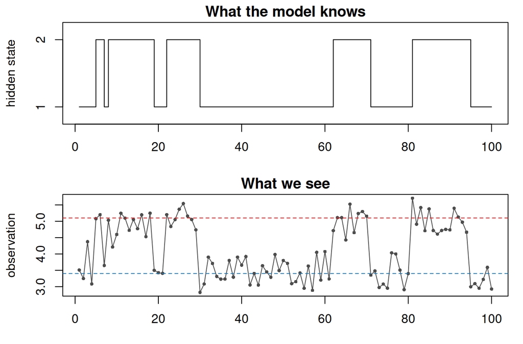

Figure 2

```r
par(mfrow = c(2, 1), mar = c(3.2, 4.2, 1.5, 1))
plot(x, type = "s", ylim = c(0.8, 2.2), yaxt = "n",
     ylab = "hidden state", xlab = "", main = "What the model knows")
axis(2, at = 1:2)
plot(y, type = "o", pch = 16, cex = 0.6, col = "grey30",
     ylab = "observation", xlab = "time", main = "What we see")
abline(h = mu, lty = 2, col = c("#1f78b4", "#e31a1c"))
par(mfrow = c(1, 1))
```

The hidden sequence is in the top panel; in real life we only have the bottom one. Our task is to work backwards from the bottom panel to the top one.

**NoteWhy the states are only *partly* recoverable**

The two state means are 3.4 and 5.1, and the standard deviation within a state is 0.4 — so the distributions barely overlap and a single observation almost tells you the state. Increase `sdv` to 1.2 and the clouds merge: then the *sequence* (through $\Gamma$) carries most of the information, not the individual value. HMMs borrow strength from both.

# 4 From data back to states

Given only `y`, an HMM is fitted by **maximum likelihood**. You do not need the details, but you should know what the machinery does.

- **Likelihood.** We cannot see the state sequence, so the likelihood sums over *all possible* state paths. There are $2^{100}$ of those in our example, which sounds hopeless, but a recursion called the **forward algorithm** computes the sum in a single sweep through the series. The optimiser (usually **EM**) then maximises it.
- **Decoding.** Once the parameters are estimated, we ask where the system was:
  - the **most likely path** over the whole series — the *Viterbi* algorithm (one state per time step, the “global” answer);
  - the **state probabilities** $\Pr(x_t = i \mid \text{all data})$ for each $t$ — the “local” answer, which also tells you how *certain* the classification is.

**WarningTwo practical traps**

**Label switching.** Nothing in the model says which state is “state 1”. A refit may return the same solution with the labels swapped. Always identify states by their estimated means, never by their number.

**Local maxima.** The likelihood surface is bumpy, so EM can converge to a poor solution depending on where it starts. Refit from several random starting values and keep the best log-likelihood (Exercise C).

# 5 Fitting an HMM in R

`depmixS4` needs the data in a **data frame** and works in three steps.

```r
sim <- data.frame(y = y)

mod <- depmix(y ~ 1, nstates = 2, data = sim)   # 1. specify
set.seed(42)
fm  <- fit(mod, verbose = FALSE)                # 2. fit
```

```
converged at iteration 16 with logLik: -68.23876
```

```r
summary(fm)                                     # 3. inspect
```

```
Initial state probabilities model
pr1 pr2
  1   0

Transition matrix
        toS1  toS2
fromS1 0.908 0.092
fromS2 0.115 0.885

Response parameters
Resp 1 : gaussian
    Re1.(Intercept) Re1.sd
St1           3.411  0.367
St2           4.998  0.324
```

Reading the output:

- `y ~ 1` means “each state has its own intercept”, i.e. its own mean. The default response distribution is Gaussian.
- *Initial state probabilities* — where the chain started.
- *Transition matrix* — the estimate of $\Gamma$.
- *Response parameters* — the mean and standard deviation per state, i.e. the observation model. Note that `depmixS4` estimates a **separate standard deviation for each state**, even though we simulated the data with the same value in both.

Compare that with the truth we simulated from:

```r
Gamma                          # true transition matrix
```

```
       to 1 to 2
from 1  0.9  0.1
from 2  0.2  0.8
```

```r
mu                             # true state means
```

```
[1] 3.4 5.1
```

The estimates should be close to 0.9/0.8 on the diagonal and to 3.4 and 5.1, possibly with the two states in the other order (label switching).

## 5.1 Getting the numbers out

Printing is fine for reading, but for plots and tables we need the values themselves. For an intercept-only model `depmixS4` stores each row of the transition matrix as a set of probabilities:

```r
tpm <- function(fm) {
  G <- t(sapply(fm@transition,
                function(tr) as.numeric(tr@parameters$coefficients)))
  stopifnot(all(abs(rowSums(G) - 1) < 1e-6))     # guard against mistakes
  dimnames(G) <- list(paste0("from S", seq_len(nrow(G))),
                      paste0("to S",   seq_len(ncol(G))))
  G
}

state_means <- function(fm) {
  sapply(fm@response, function(r) as.numeric(r[[1]]@parameters$coefficients))
}

round(tpm(fm), 3)
```

```
        to S1 to S2
from S1 0.908 0.092
from S2 0.115 0.885
```

```r
round(state_means(fm), 2)
```

```
[1] 3.41 5.00
```

And the decoded states:

```r
post <- posterior(fm, type = "viterbi")
head(round(post, 3))
```

```
  state    S1    S2
1     1 1.000 0.000
2     1 1.000 0.000
3     1 0.629 0.371
4     1 1.000 0.000
5     2 0.000 1.000
6     2 0.000 1.000
```

```r
mean(post$state == x)      # fraction of time steps classified correctly
```

```
[1] 1
```

The column `state` is the Viterbi path; `S1` and `S2` are the state probabilities. Because we simulated the data we can do something you can never do with real data: check the classification against the truth.

**Tip**

If that fraction is close to 0 rather than 1, the labels are swapped — try `mean(post$state == 3 - x)`. That is label switching, not a bad model.

# 6 How many states?

$N$ is a modelling choice. Fit several models and compare them with AIC or BIC, which balance fit against the number of parameters:

```r
set.seed(42)
fits <- lapply(1:3, function(k)
  fit(depmix(y ~ 1, nstates = k, data = sim), verbose = FALSE))
```

```
converged at iteration 1 with logLik: -126.9845
converged at iteration 16 with logLik: -68.23876
converged at iteration 120 with logLik: -63.38375
```

```r
data.frame(states = 1:3,
           logLik = round(sapply(fits, logLik), 1),
           npar   = sapply(fits, freepars),
           AIC    = round(sapply(fits, AIC), 1),
           BIC    = round(sapply(fits, BIC), 1))
```

```
  states logLik npar   AIC   BIC
1      1 -127.0    2 258.0 263.2
2      2  -68.2    7 150.5 168.7
3      3  -63.4   14 154.8 191.2
```

The two-state model should win, as it should — that is how we generated the data.

**ImportantDo not let AIC decide alone**

With real data, consider as well:

- **interpretability** — can you name the states biologically?
- **stability** — do the estimates survive refitting from other starting values?
- **residual checks** — does the fitted model reproduce the features you care about?

Adding states almost always improves the likelihood. Pohle et al. (2017) is the standard warning on this; see **Further reading** at the end of this module.

# Part II – Worked examples

# 7 Example: regimes in the river Nile

`Nile` holds the annual flow at Aswan, 1871–1970, in $10^8$ m³.

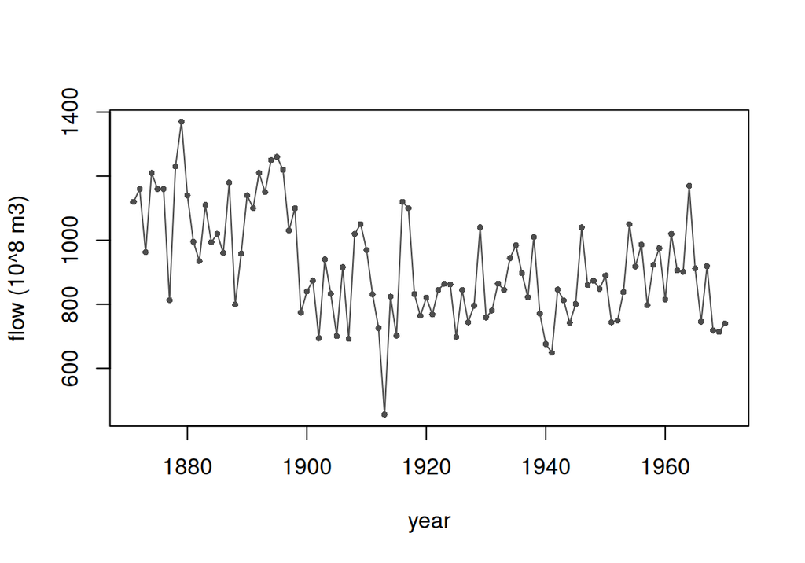

Figure 3

```r
nile <- data.frame(year = as.numeric(time(Nile)), flow = as.numeric(Nile))
plot(nile$year, nile$flow, type = "o", pch = 16, cex = 0.6, col = "grey30",
     xlab = "year", ylab = "flow (10^8 m3)")
```

Flow looks higher in the early decades. The question is whether that impression survives a model — a century of a noisy series will always contain stretches that happen to look high or low.

We fit a two-state Gaussian HMM. Note what we do **not** do: we never tell the model when the change happened.

```r
set.seed(42)
nile_hmm <- fit(depmix(flow ~ 1, nstates = 2, data = nile), verbose = FALSE)
```

```
converged at iteration 29 with logLik: -629.8045
```

```r
round(tpm(nile_hmm), 3)
```

```
        to S1 to S2
from S1 0.964 0.036
from S2 0.000 1.000
```

```r
round(state_means(nile_hmm))
```

```
[1] 1097  851
```

One state has a mean near 1100, the other near 850. Now decode and plot:

```
[1] 1899
```

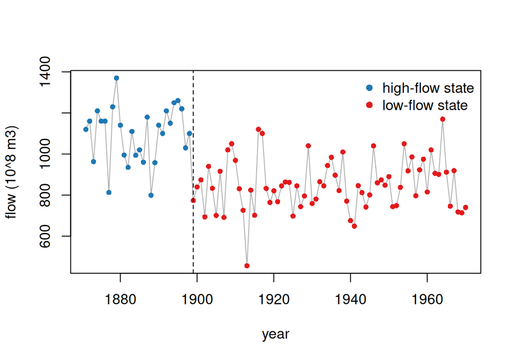

Figure 4

```r
np <- posterior(nile_hmm, type = "viterbi")
low <- which.min(state_means(nile_hmm))          # identify states by their means!

plot(nile$year, nile$flow, type = "l", col = "grey70",
     xlab = "year", ylab = "flow (10^8 m3)")
points(nile$year, nile$flow, pch = 16, cex = 0.8,
       col = ifelse(np$state == low, "#e31a1c", "#1f78b4"))
abline(v = 1899, lty = 2)
legend("topright", c("high-flow state", "low-flow state"), pch = 16, bty = "n",
       col = c("#1f78b4", "#e31a1c"))

nile$year[which(diff(np$state) != 0) + 1]        # year(s) of switching
```

The model finds a single switch, and places it at **1899** — which is when construction of the Aswan Low Dam began (1898–1902). The dashed line was drawn afterwards, as a check on the answer.

How certain is the switch? Plot the state probability rather than the path:

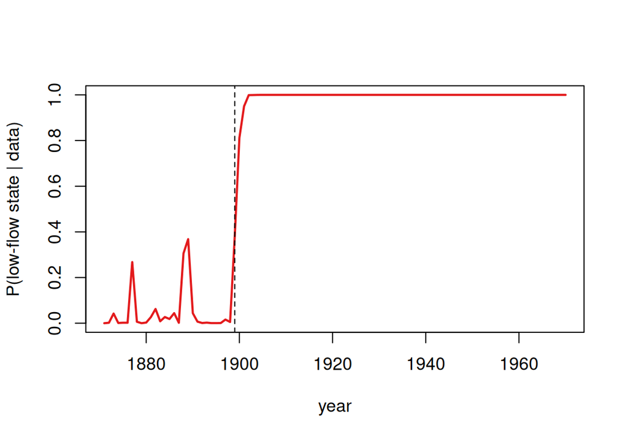

Figure 5

```r
plot(nile$year, np[[paste0("S", low)]], type = "l", lwd = 2, col = "#e31a1c",
     ylim = c(0, 1), xlab = "year", ylab = "P(low-flow state | data)")
abline(v = 1899, lty = 2)
```

The probability goes from almost 0 to almost 1 within a couple of years: a sharp, well-identified transition.

**NoteAn honest look at the transition matrix**

The estimated probability of returning to the high-flow state is essentially zero, so the fitted chain is **absorbing**: once low, always low. For these data that is the right answer — one structural, one-way change. But it means the usual summaries (stationary distribution, expected dwell time in the low state) are no longer meaningful, and the formula $1/(1-\gamma_{22})$ returns a nonsensically large number. Regimes that genuinely recur, as in lakes or oceans, are the more typical HMM application.

# 8 Example: clear and turbid lakes

Shallow lakes have two **alternative stable states**: *clear* (plants dominate) and *turbid* (algae dominate). Vitense et al. (2021) sampled 123 Minnesota lakes once per summer for three years. Let us first pretend the state *is* observed, by labelling a lake-year turbid when chlorophyll *a* exceeds 20 µg/L:

```r
turbid <- function(chla) as.integer(chla > 20)
S <- data.frame(y09 = turbid(lakes$Chla09),
                y10 = turbid(lakes$Chla10),
                y11 = turbid(lakes$Chla11))
round(colMeans(S), 2)            # fraction turbid per year
```

```
 y09  y10  y11
0.18 0.20 0.32
```

Each lake gives two one-year transitions (2009→2010 and 2010→2011). Stack them and count:

```r
steps <- rbind(data.frame(now = S$y09, nxt = S$y10, TP = lakes$TP09),
               data.frame(now = S$y10, nxt = S$y11, TP = lakes$TP10))
steps <- steps[complete.cases(steps), ]

cnt <- table(from = steps$now, to = steps$nxt)   # 0 = clear, 1 = turbid
cnt
```

```
    to
from   0   1
   0 174  26
   1   9  37
```

```r
round(prop.table(cnt, 1), 3)                     # the transition matrix
```

```
    to
from     0     1
   0 0.870 0.130
   1 0.196 0.804
```

Here is the useful connection: estimating a transition matrix for an **observed** two-state chain is just **logistic regression on the previous state**.

```r
m1 <- glm(nxt ~ now, data = steps, family = binomial)
c(clear_to_turbid = plogis(coef(m1)[[1]]),
  turbid_to_turbid = plogis(coef(m1)[[1]] + coef(m1)[[2]]))
```

```
 clear_to_turbid turbid_to_turbid
       0.1300000        0.8043478
```

```r
m2 <- glm(nxt ~ now + log(TP), data = steps, family = binomial)
round(summary(m2)$coefficients[, c(1, 2, 4)], 3)
```

```
            Estimate Std. Error Pr(>|z|)
(Intercept)   -6.896      1.178    0.000
now            1.761      0.515    0.001
log(TP)        1.289      0.283    0.000
```

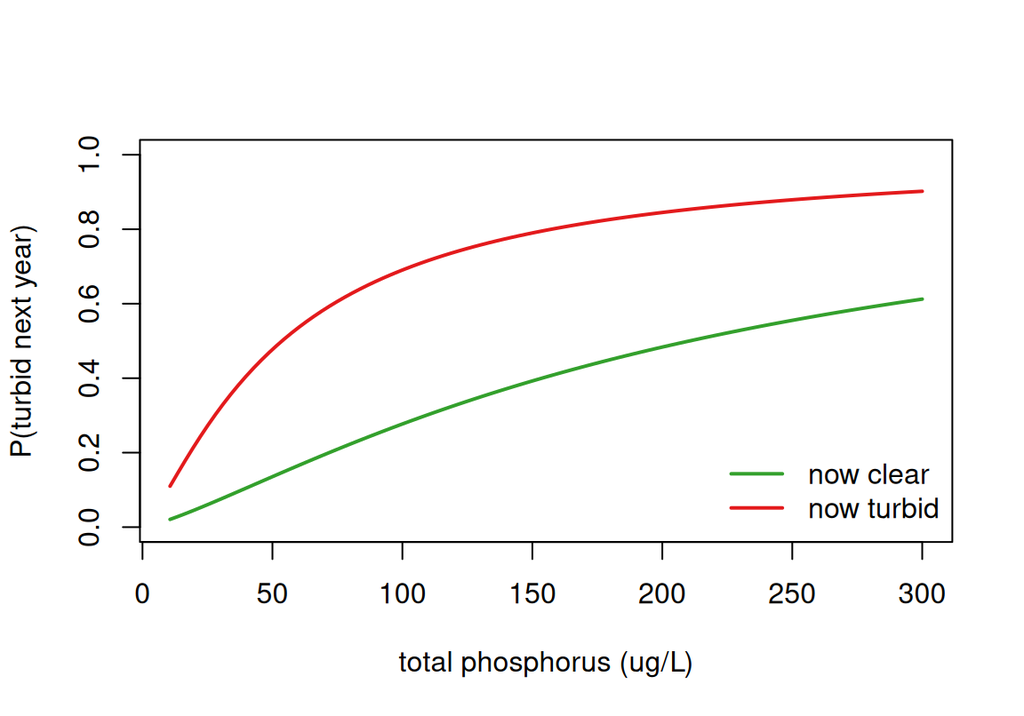

Figure 6

```r
tp <- seq(min(steps$TP), 300, length.out = 100)
p_clear  <- predict(m2, data.frame(now = 0, TP = tp), type = "response")
p_turbid <- predict(m2, data.frame(now = 1, TP = tp), type = "response")
plot(tp, p_clear, type = "l", lwd = 2, col = "#33a02c", ylim = c(0, 1),
     xlab = "total phosphorus (ug/L)", ylab = "P(turbid next year)")
lines(tp, p_turbid, lwd = 2, col = "#e31a1c")
legend("bottomright", c("now clear", "now turbid"), lwd = 2, bty = "n",
       col = c("#33a02c", "#e31a1c"))
```

More phosphorus, higher probability of being turbid next year — whatever the lake’s current state.

**ImportantWhy this is *not* yet the published analysis**

We treated our 20 µg/L rule as the truth. But a lake at 19 or 21 µg/L has been classified with a confidence it does not deserve, and one summer sample is a noisy view of a whole lake-year. Misclassified states bias every transition probability, usually towards **too much switching**.

That is exactly why Vitense et al. (2021) treat the lake state as **hidden** and fit an HMM: chlorophyll, vegetation and nutrients become *observations* generated by the state, and the state itself is estimated. Their paper is in `hmm_papers/Vitense2021_JApplEcol_shallow_lakes/`.

# Part III – Exercises and solutions

Write a separate script (`Ex_HMM.R`) so your module code stays unchanged. Exercises A and B use only Part I; C–F build on the later sections.

**Important**

Try each exercise yourself before opening its solution.

# 9 Exercise A: reading a transition matrix

A two-state HMM for an ocean regime has

$$\Gamma = \begin{bmatrix} 0.95 & 0.05 \\ 0.30 & 0.70 \end{bmatrix},$$

where state 1 is “cool” and state 2 is “warm”.

1. Build `G` in R and check that its rows sum to 1.
2. The ocean is cool this year. What is the probability that it is warm in two years’ time?
3. What is the expected length of a cool period, and of a warm period?
4. What fraction of years are cool in the long run? Compute it by iteration.
5. Without fitting anything: which state would you expect to see in longer uninterrupted runs in a time series simulated from this matrix?

**TipSolution A**

**1.**

```r
G <- matrix(c(0.95, 0.05,
              0.30, 0.70), nrow = 2, byrow = TRUE)
rowSums(G)
```

```
[1] 1 1
```

**2.** Two steps ahead is $\Gamma^2$; we need row 1, column 2.

```r
(G %*% G)[1, 2]
```

```
[1] 0.0825
```

**3.**

```r
1 / (1 - diag(G))
```

```
[1] 20.000000  3.333333
```

Cool periods last 20 years on average, warm periods about 3.3 years.

**4.**

```r
d <- c(1, 0)
for (i in 1:500) d <- d %*% G
round(d, 3)
```

```
      [,1]  [,2]
[1,] 0.857 0.143
```

About 86% of years are cool.

**5.** The cool state, because it is far more persistent (0.95 versus 0.70) — and the dwell times in part 3 put numbers on that intuition.

# 10 Exercise B: simulate and look

*Builds on Section 3.*

Use the matrix `G` from Exercise A, with state means 12.5 °C (cool) and 14.0 °C (warm) and a standard deviation of 0.5 °C in both states.

1. Simulate 150 years of hidden states and of temperature observations. Plot both, one above the other.
2. Can you see the regimes by eye in the observations alone?
3. Now raise the standard deviation to 1.5 °C and simulate again (keep the same seed and the same states). What happens to your ability to see the regimes?
4. Return to sd = 0.5 but change the diagonal of `G` to 0.5/0.5. How does the series change, and why?

**TipSolution B**

**1.**

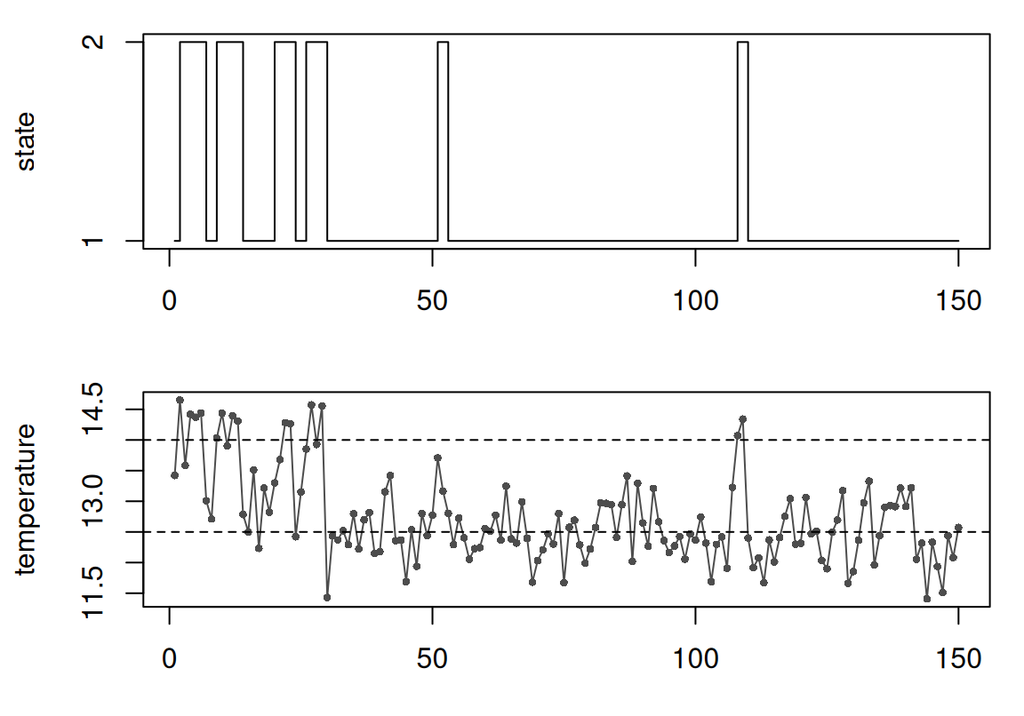

```r
set.seed(7)
n <- 150
mu_B <- c(12.5, 14.0)

sim_states <- function(n, G, start = 1) {
  x <- numeric(n); x[1] <- start
  for (t in 2:n) x[t] <- sample(1:nrow(G), 1, prob = G[x[t - 1], ])
  x
}

xB <- sim_states(n, G)
yB <- rnorm(n, mu_B[xB], 0.5)

par(mfrow = c(2, 1), mar = c(3.2, 4.2, 1, 1))
plot(xB, type = "s", yaxt = "n", ylab = "state", xlab = "")
axis(2, at = 1:2)
plot(yB, type = "o", pch = 16, cex = 0.6, col = "grey30",
     ylab = "temperature", xlab = "year")
abline(h = mu_B, lty = 2)
```

```r
par(mfrow = c(1, 1))
```

**2.** Yes — with sd = 0.5 and means 1.5 apart, the two levels are clearly separated, and warm spells show up as short excursions.

**3.**

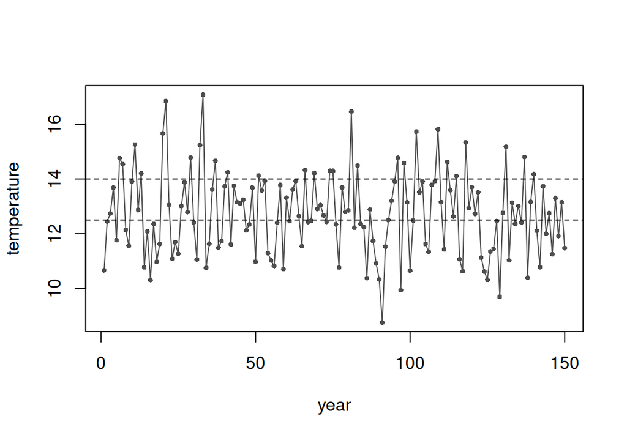

```r
yB_noisy <- rnorm(n, mu_B[xB], 1.5)
plot(yB_noisy, type = "o", pch = 16, cex = 0.6, col = "grey30",
     ylab = "temperature", xlab = "year")
abline(h = mu_B, lty = 2)
```

**4.**

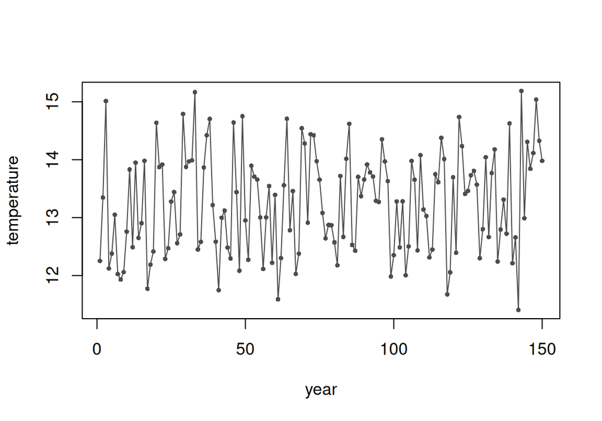

```r
G_flip <- matrix(c(0.5, 0.5,
                   0.5, 0.5), nrow = 2, byrow = TRUE)
x_flip <- sim_states(n, G_flip)
y_flip <- rnorm(n, mu_B[x_flip], 0.5)
plot(y_flip, type = "o", pch = 16, cex = 0.6, col = "grey30",
     ylab = "temperature", xlab = "year")
```

With a diagonal of 0.5 the state is a coin flip each year: the runs disappear and the series jumps up and down. There are still two states, but no *regimes* — persistence is what makes a regime.

# 11 Exercise C: fit, and check against the truth

*Builds on Section 5 and Section 4.*

Use the data `yB` you simulated in Exercise B (sd = 0.5).

1. Fit a two-state Gaussian HMM with `depmixS4`. Compare the estimated transition matrix and state means with the values you simulated from.
2. Decode the states and compute the fraction of years classified correctly. Watch out for label switching.
3. Refit the model 20 times from different seeds and collect the log-likelihoods. Are they all the same? Keep the best fit.
4. Repeat steps 1 and 2 on the noisy data `yB_noisy` (sd = 1.5). Look at the estimated means *and* standard deviations, and at `table(decoded, true)`. Did the model find the two regimes you simulated? Compare its accuracy with the accuracy of the trivial rule “always guess the more common state”.

**TipSolution C**

**1.**

```r
dB <- data.frame(y = yB)
set.seed(11)
fB <- fit(depmix(y ~ 1, nstates = 2, data = dB), verbose = FALSE)
```

```
converged at iteration 27 with logLik: -121.6747
```

```r
round(tpm(fB), 3); G
```

```
        to S1 to S2
from S1 0.923 0.077
from S2 0.012 0.988
```

```
     [,1] [,2]
[1,] 0.95 0.05
[2,] 0.30 0.70
```

```r
round(state_means(fB), 2); mu_B
```

```
[1] 13.71 12.46
```

```
[1] 12.5 14.0
```

**2.**

```r
pB <- posterior(fB, type = "viterbi")
cool <- which.min(state_means(fB))          # identify by the means
est <- ifelse(pB$state == cool, 1, 2)       # relabel: 1 = cool
mean(est == xB)
```

```
[1] 0.9066667
```

**3.**

```r
ll <- sapply(1:20, function(s) {
  set.seed(s)
  logLik(fit(depmix(y ~ 1, nstates = 2, data = dB), verbose = FALSE))
})
```

```
converged at iteration 27 with logLik: -121.6747
converged at iteration 28 with logLik: -121.6747
converged at iteration 27 with logLik: -121.6747
converged at iteration 34 with logLik: -121.6747
converged at iteration 27 with logLik: -121.6747
converged at iteration 27 with logLik: -121.6747
converged at iteration 28 with logLik: -121.6747
converged at iteration 27 with logLik: -121.6747
converged at iteration 25 with logLik: -121.6747
converged at iteration 27 with logLik: -121.6747
converged at iteration 27 with logLik: -121.6747
converged at iteration 29 with logLik: -121.6747
converged at iteration 26 with logLik: -121.6747
converged at iteration 28 with logLik: -121.6747
converged at iteration 27 with logLik: -121.6747
converged at iteration 35 with logLik: -121.6747
converged at iteration 27 with logLik: -121.6747
converged at iteration 26 with logLik: -121.6747
converged at iteration 26 with logLik: -121.6747
converged at iteration 26 with logLik: -121.6747
```

```r
round(range(ll), 2)
```

```
[1] -121.67 -121.67
```

```r
sum(abs(ll - max(ll)) > 0.01)               # how many runs missed the best fit
```

```
[1] 0
```

With well-separated states nearly every run finds the same optimum. With overlapping states or more than two states this is no longer true, which is why refitting is standard practice.

**4.**

```r
dN <- data.frame(y = yB_noisy)
set.seed(11)
fN <- fit(depmix(y ~ 1, nstates = 2, data = dN), verbose = FALSE)
```

```
converged at iteration 275 with logLik: -270.5387
```

```r
round(state_means(fN), 2); mu_B
```

```
[1] 12.91 10.80
```

```
[1] 12.5 14.0
```

```r
round(sapply(fN@response, function(r) as.numeric(r[[1]]@parameters$sd)), 2)
```

```
[1] 1.46 0.28
```

```r
round(tpm(fN), 3)
```

```
        to S1 to S2
from S1 0.926 0.074
from S2 0.854 0.146
```

```r
pN <- posterior(fN, type = "viterbi")
table(decoded = pN$state, true = xB)
```

```
       true
decoded   1   2
      1 116  22
      2  12   0
```

This is the interesting failure, and it is worth reading slowly. The model did **not** recover the simulated regimes. It found

- a broad state (mean 12.91, sd 1.46) that covers most of the series, and
- a narrow state (mean 10.80, sd 0.28) that collects a dozen unusually low values.

In the cross-table, the decoded “low” state contains **no** truly warm years at all: the model has split the *noise* rather than the *regimes*. Accuracy under the best of the two label mappings is

```r
coolN <- which.min(state_means(fN))
a1 <- mean(ifelse(pN$state == coolN, 1, 2) == xB)
c(by_means = a1, swapped = 1 - a1, baseline_always_cool = mean(xB == 1))
```

```
            by_means              swapped baseline_always_cool
           0.2266667            0.7733333            0.8533333
```

— worse than simply guessing “cool” every year. With means 1.5 apart and a standard deviation of 1.5, 150 observations and a chain this persistent are simply not enough information. Same model, same sample size: only the signal-to-noise ratio changed.

**Note**

This is also why the `which.min()` trick for relabelling is not a cure-all: it assumes the fitted states *correspond* to the simulated ones. When they do not, no relabelling will help, and the honest conclusion is that the model is not identifying the regimes.

# 12 Exercise D: how many states for the Nile?

*Builds on Section 7 and Section 6.*

1. Fit HMMs with one, two and three states to the Nile data and tabulate log-likelihood, number of parameters, AIC and BIC.
2. Which model do AIC and BIC prefer? Do they agree?
3. Look at the state means of the three-state model. Would you be able to give the extra state a hydrological meaning?
4. For the two-state model, how many years have a state probability between 0.1 and 0.9 — that is, how many years are genuinely ambiguous?

**TipSolution D**

**1.**

```r
set.seed(42)
nile_fits <- lapply(1:3, function(k)
  fit(depmix(flow ~ 1, nstates = k, data = nile), verbose = FALSE))
```

```
converged at iteration 1 with logLik: -654.5157
converged at iteration 29 with logLik: -629.8045
converged at iteration 59 with logLik: -627.8478
```

```r
data.frame(states = 1:3,
           logLik = round(sapply(nile_fits, logLik), 1),
           npar   = sapply(nile_fits, freepars),
           AIC    = round(sapply(nile_fits, AIC), 1),
           BIC    = round(sapply(nile_fits, BIC), 1))
```

```
  states logLik npar    AIC    BIC
1      1 -654.5    2 1313.0 1318.2
2      2 -629.8    7 1273.6 1291.8
3      3 -627.8   14 1283.7 1320.2
```

**2.** Both prefer the two-state model: one state is clearly too few, and the third state improves the likelihood but not enough to pay for its extra parameters.

**3.**

```r
round(sort(state_means(nile_fits[[3]])))
```

```
[1]  851  999 1192
```

The three means split one of the two regimes into a slightly higher and a slightly lower level. There is no known hydrological event to attach to that split, so it is best read as the model chasing noise — exactly the situation where interpretability should override a small likelihood gain.

**4.**

```r
p2 <- posterior(nile_fits[[2]], type = "viterbi")
sum(p2$S1 > 0.1 & p2$S1 < 0.9)
```

```
[1] 5
```

Only a handful of years are ambiguous; the rest are classified almost without doubt.

# 13 Exercise E: lakes, transitions and covariates

*Builds on Section 8.*

1. Rebuild the clear/turbid transition matrix using a threshold of 10 µg/L instead of 20 µg/L. How do the persistence probabilities change, and why?
2. With the 20 µg/L threshold, fit the logistic regression with submerged vegetation (`SAVperc09` / `SAVperc10`) as a covariate instead of phosphorus. What is the sign of the effect, and does it make ecological sense?
3. The lakes were each sampled only three times. Explain in two or three sentences why that makes the estimated transition probabilities shaky, even with 123 lakes.
4. Explain why treating “chlorophyll > 20” as the state is a *measurement* problem, and what an HMM does about it.

**TipSolution E**

**1.**

```r
turbid10 <- function(chla) as.integer(chla > 10)
S10 <- data.frame(y09 = turbid10(lakes$Chla09),
                  y10 = turbid10(lakes$Chla10),
                  y11 = turbid10(lakes$Chla11))
st10 <- rbind(data.frame(now = S10$y09, nxt = S10$y10),
              data.frame(now = S10$y10, nxt = S10$y11))
st10 <- st10[complete.cases(st10), ]
round(prop.table(table(from = st10$now, to = st10$nxt), 1), 3)
```

```
    to
from     0     1
   0 0.782 0.218
   1 0.224 0.776
```

**2.**

```r
steps_sav <- rbind(data.frame(now = S$y09, nxt = S$y10, SAV = lakes$SAVperc09),
                   data.frame(now = S$y10, nxt = S$y11, SAV = lakes$SAVperc10))
steps_sav <- steps_sav[complete.cases(steps_sav), ]
m3 <- glm(nxt ~ now + SAV, data = steps_sav, family = binomial)
round(summary(m3)$coefficients[, c(1, 2, 4)], 3)
```

```
            Estimate Std. Error Pr(>|z|)
(Intercept)   -1.121      0.490    0.022
now            2.957      0.463    0.000
SAV           -1.036      0.607    0.088
```

The coefficient for `SAV` is negative: the more stations with submerged vegetation, the lower the probability of being turbid next year. That matches the ecology of alternative stable states — macrophytes stabilise the clear state (they compete with algae for nutrients, and they trap sediment).

**3.** Three annual samples give only two transitions per lake, and almost all of those are “stayed in the same state”. The off-diagonal probabilities therefore rest on a few dozen observed switches, so they have wide confidence intervals; and nothing in three years lets you separate a real switch from a misclassified sample.

**4.** The state (clear or turbid) is a property of the lake; chlorophyll is a *noisy measurement* of it from a single summer sample. Thresholding converts an uncertain measurement into a hard label and then treats that label as data, which propagates classification error into every estimate. An HMM instead makes chlorophyll an **observation generated by the state**, estimates the state distributions and the transition probabilities together, and reports the state as a probability rather than a label.

# 14 Exercise F: find the HMM in a paper

*Builds on the whole module.*

Open one of the papers in `../hmm_papers/` — for example `Rand2024_EcolModel_ecosystem_indicators/` (ocean regimes), `Goldstein2024_MEE_cameratrap_occupancy/` (occupancy from camera traps) or `Hollanders2022_MEE_frog_disease/` (infection state in capture–recapture) — and read the abstract plus the methods section describing the model.

Then answer, in a few sentences each:

1. What is the **hidden state**, and how many states does the model use?
2. What are the **observations**, and which distribution is used for them?
3. Are there **covariates**, and do they act on the state means, on the transition probabilities, or on both?
4. What did treating the state as hidden *buy* the authors that a simpler analysis would have missed?

**TipSolution F**

There is no single right answer; this is a reading exercise. For Rand et al. (2024), *Using Hidden Markov Models to develop ecosystem indicators from non-stationary time series*:

1. **Hidden state:** the ecosystem regime of the California Current — cool, average or warm ocean conditions. The paper compares models with different numbers of states and settles on three for the temperature indicators.
2. **Observations:** annual ocean-condition indicator series (temperature at two depths and in two seasons) and seabird density anomalies, modelled as Gaussian; several indicators are modelled jointly, which makes it a *multivariate* HMM.
3. **Covariates:** the paper’s point is that the series are **non-stationary** — there is a trend in the means — so time enters the state means; HMMs in general also allow covariates on the transition probabilities.
4. **What it buys them:** NOAA’s established “stoplight” charts classify each year into terciles, which cannot distinguish a genuine regime change from noise and ignores the trend. The HMM estimates the regimes *and* the probability of being in each one, so the indicator comes with uncertainty and can be updated each year.

Check your own answer against the data and code in the paper’s folder: the hidden state should be something *unobservable but interpretable*, and the observation model should be the distribution of the measurements actually taken.

# Summary

| Task | Key functions |
| --- | --- |
| Build / check a transition matrix | `matrix(..., byrow = TRUE)`, `rowSums()` |
| $k$-step transitions, stationary distribution | `%*%`, iteration in a `for()` loop |
| Expected dwell time | `1 / (1 - diag(G))` |
| Simulate hidden states | `sample(1:N, 1, prob = G[x[t-1], ])` |
| Simulate observations | `rnorm(n, mu[x], sd[x])` |
| Specify and fit an HMM | `depmix(y ~ 1, nstates = , data = )`, `fit()` |
| Inspect a fit | `summary()`, `logLik()`, `AIC()`, `BIC()`, `freepars()` |
| Decode states | `posterior(fm, type = "viterbi")` |

Every HMM analysis in this module follows the same recipe:

1. decide how many states, and what distribution the data follow in each;
2. fit the model — the states are estimated, not supplied;
3. decode: which state was the system in, and how certain is that?
4. check: refit from other starting values, compare numbers of states, and ask whether the states mean anything biologically.

| Example | Hidden state | Observations |
| --- | --- | --- |
| Simulated series (Section 3) | two states, known truth | normal |
| River Nile (Section 7) | high- vs low-flow regime | normal, annual flow |
| Shallow lakes (Section 8) | clear vs turbid lake | chlorophyll (here thresholded) |

**NoteWhere to go next**

- `depmixS4` is a good first package to look at; it has an informative tutorial (‘vignette’ in R-jargon)
- the packages `hmmTMB` - smooth (spline) and random effects on the means and the transition probabilities
- `moveHMM` / `momentuHMM`— HMMs for animal tracking data (step lengths and turning angles)

# Sources and material used

- The lake example uses the data archive of **Vitense, K., M. A. Hanson, B. R. Herwig, K. D. Zimmer & J. Fieberg (2021)**, *Using hidden Markov models to inform conservation and management strategies in ecosystems exhibiting alternative stable states*, Journal of Applied Ecology 58: 1069–1078, doi:10.1111/1365-2664.13855; data at doi:10.13020/sm2d-fk79, copied in `../hmm_papers/Vitense2021_JApplEcol_shallow_lakes/`.
- Exercise F refers to the paper collection in `../hmm_papers/` (see its `README.md`).

# Further reading

- Zucchini, W., MacDonald, I. L. & Langrock, R. (2016). *Hidden Markov Models for Time Series: An Introduction Using R*, 2nd ed. CRC Press. The standard textbook, with exercises.
- McClintock, B. T. et al. (2020). Uncovering ecological state dynamics with hidden Markov models. *Ecology Letters* 23: 1878–1903. The best overview for ecologists.
- Glennie, R. et al. (2023). Hidden Markov models: pitfalls and opportunities in ecology. *Methods in Ecology and Evolution* 14: 43–56.
- Pohle, J., Langrock, R., van Beest, F. M. & Schmidt, N. M. (2017). Selecting the number of states in hidden Markov models: pitfalls, practical challenges and pragmatic solutions. *JABES* 22: 270–293. https://arxiv.org/abs/1701.08673
- Visser, I. & Speekenbrink, M. (2010). depmixS4: an R package for hidden Markov models. *Journal of Statistical Software* 36: 1–21.